# 異なる難易度のテスト項目のIRT垂直尺度化

2019/1/10

## 問題関心

国語や算数，数学などの教科は学年をまたいで内容が継続して学習されるため，一回のテストの結果だけを参考に学力を評価するよりも，これまでのテストの得点を考慮して，**学力の伸び**を評価する方が適しているのではないか。

その伸びを測るための尺度を，異なる難易度のテスト項目を**IRTモデル**により**対応づけ(linking)**して構成する方法が，**垂直尺度化**である。

## IRTモデル

受検者の特性（能力）と項目の特性（困難度，識別力）をモデル上で独立に定義している。

- 特定の項目，テストに依存しない受検者の能力が推定できる。
- 項目の特性値だけを取り出して，共通尺度化できる。

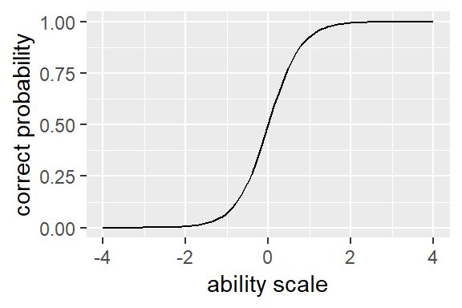

## 垂直尺度化

IRTのパラメタの不定性を利用して，異なる複数のテスト項目のパラメタを共通尺度上に位置づける＝対応づけ。  
その中でも，異なる学年で実施され，テストの難易度が異なる場合のものを垂直尺度化と呼ぶ。

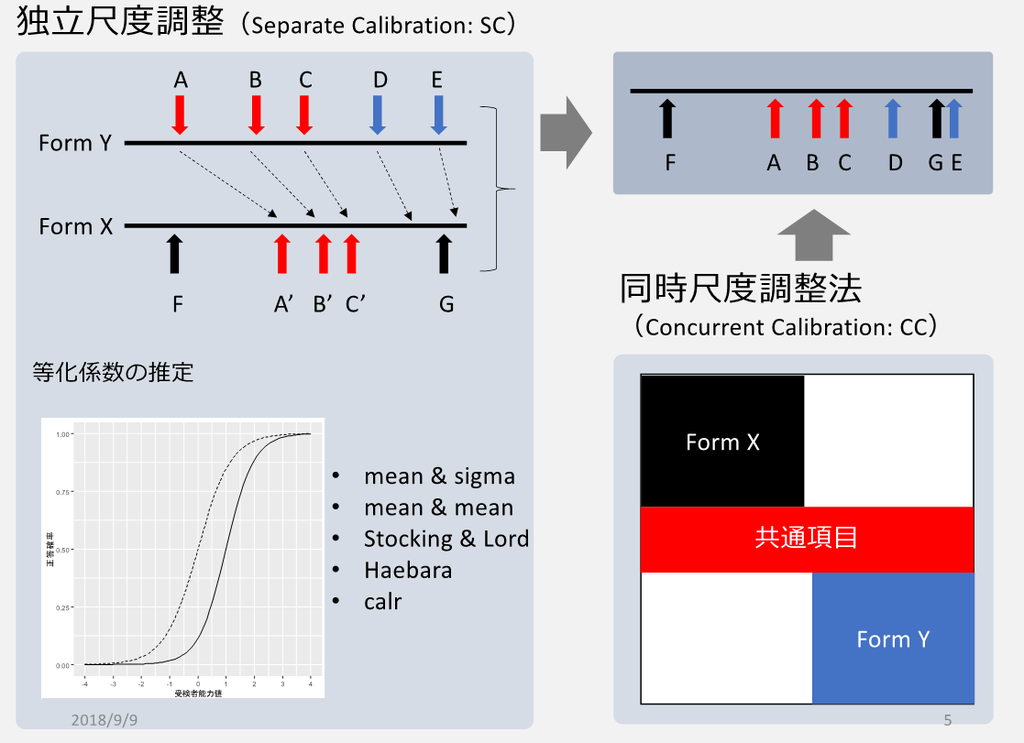

## 実験

### 尺度化テストデザインに適した尺度調整法の検討

### 実データを用いた垂直尺度構成